# AFM 346 Final Project - Low-Complexity Model

Derek Shat

12/15/2021

```r
library(tidyverse)
library(readxl)
library(tidymodels)
library(GGally)
library(knitr)
library(doParallel)
library(tictoc)
library(janitor)
```

```r
credit_raw <- read_xls("default of credit card clients.xls", skip = 1)

credit_dt <- credit_raw %>%
  clean_names() %>%
        select(default = default_payment_next_month,
               everything()) %>%
  mutate(across(.cols = c('default','sex',
                          'education', 'marriage',
                          matches('pay_[0-9]')),
                as_factor))

set.seed(123)
credit_split <- initial_split(credit_dt, prop = 0.7, strata = default)
credit_train <- training(credit_split)
credit_test <- testing(credit_split)
set.seed(456)
credit_folds <- credit_train %>%
  vfold_cv(v = 5, repeats = 5, strata = default)

perf_meas <- metric_set(kap,f_meas,roc_auc,mn_log_loss)
```

# Low-Complexity Model

The low-complexity model chosen was the logistic regression model. This model was chosen becasue it is relatively simple and explainable. It makes the log-odds of a default occurring based on its predictors equal to a line and intercept, which can be solved to calculate a probability value between 0 and 1.

The hyperparameters used are penalty and mixture. Penalty regularizes the data by reducing the coefficients of the variables used to calculate the line and intercept, while mixture specifies what proportion of the penalty is applied by a squared magnitude (ridge regression, when mixture=0) which is the inverse of the proportion applied by an absolute value of magnitude (lasso regression, when mixture=1).

Other than the dummy variable step, some steps to transform the data, such as a step to remove variables with only a single value, a step to normalize the numeric variables, a step to create new variables representing the proportion of the bill paid, and a final step to decorrelate any highly correlated variables.

```r
low_complexity_recipe <-
  recipe(default~., data = credit_train) %>%
  step_dummy(sex:pay_6, -age) %>%
  step_zv(all_numeric_predictors(), -all_outcomes()) %>%
  step_normalize(all_numeric_predictors(), -all_outcomes())%>%
  step_mutate(prop_bill1 = pay_amt1/(bill_amt1 + 1),
              prop_bill2 = pay_amt2/(bill_amt2 + 1),
              prop_bill3 = pay_amt3/(bill_amt3 + 1),
              prop_bill4 = pay_amt4/(bill_amt4 + 1),
              prop_bill5 = pay_amt5/(bill_amt5 + 1),
              prop_bill6 = pay_amt6/(bill_amt6 + 1)) %>%
  step_corr(bill_amt1:bill_amt6, -all_outcomes())

lr_mod <-
  logistic_reg(penalty = tune(),
               mixture = tune()) %>%
  set_mode('classification') %>%
  set_engine('glmnet')


low_complexity_wf <-
  workflow() %>%
  add_recipe(low_complexity_recipe) %>%
  add_model(lr_mod)

param_lr <- grid_latin_hypercube(penalty(range(-10,-4)),
                                 mixture(range(0,1)),
                                 size = 20)


all_cores <- parallel::detectCores(logical = FALSE)
cl <- makePSOCKcluster(all_cores)
registerDoParallel(cl)

tic()
low_complexity_res <- low_complexity_wf %>%
  tune_grid(
    credit_folds,
    grid = param_lr,
    metrics = perf_meas,
    control = control_resamples(save_pred=TRUE)
    )
toc()
```

```
## 677.08 sec elapsed
```

```r
stopCluster(cl)

show_best(low_complexity_res, metric = "kap") %>% kable(digits = 3)
```

| penalty | mixture | .metric | .estimator | mean | n | std_err | .config |
| --- | --- | --- | --- | --- | --- | --- | --- |
| 0 | 0.116 | kap | binary | 0.37 | 25 | 0.004 | Preprocessor1_Model03 |
| 0 | 0.087 | kap | binary | 0.37 | 25 | 0.004 | Preprocessor1_Model02 |
| 0 | 0.011 | kap | binary | 0.37 | 25 | 0.004 | Preprocessor1_Model01 |
| 0 | 0.218 | kap | binary | 0.37 | 25 | 0.004 | Preprocessor1_Model05 |
| 0 | 0.389 | kap | binary | 0.37 | 25 | 0.004 | Preprocessor1_Model08 |

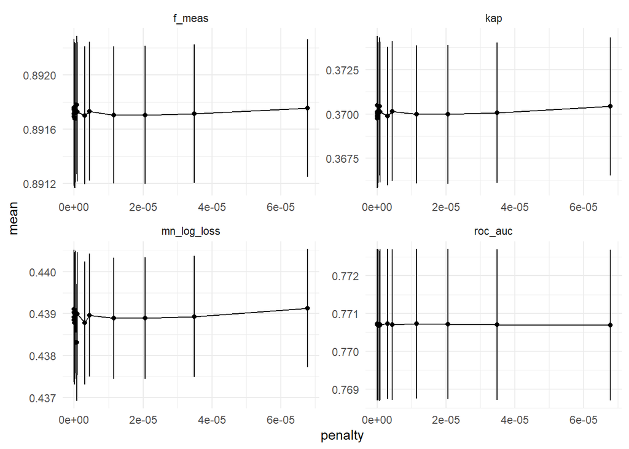

```r
low_complexity_res %>%
  collect_metrics() %>%
  ggplot(aes(x = penalty, y = mean)) +
  geom_point() +
  geom_line() +
  geom_errorbar(
    aes(ymin = mean - std_err,
        ymax = mean + std_err)) +
  facet_wrap(~.metric, scales = 'free', ncol = 2) +
  theme_minimal()
```

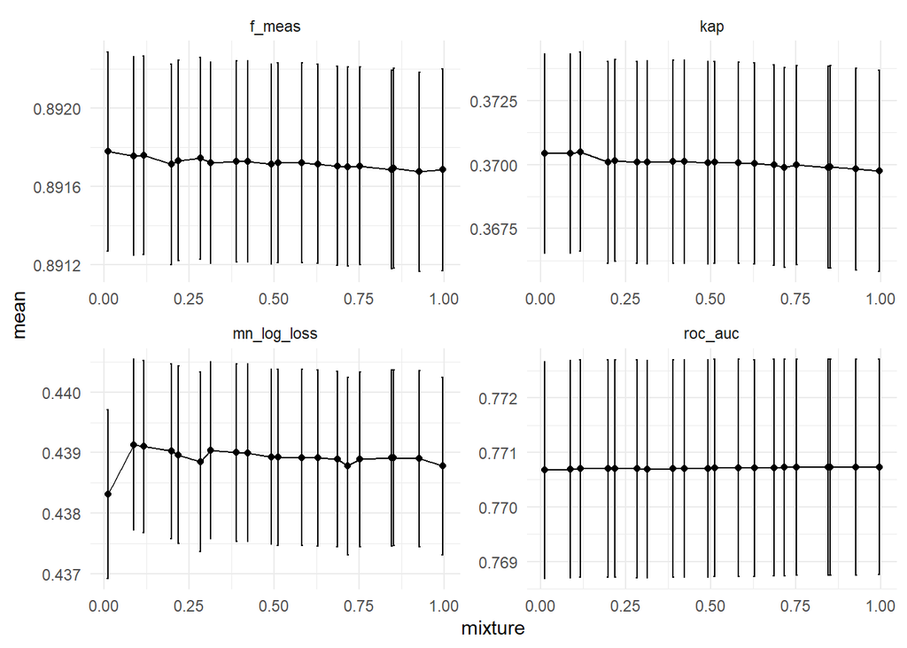

```r
low_complexity_res %>%
  collect_metrics() %>%
  ggplot(aes(x = mixture, y = mean)) +
  geom_point() +
  geom_line() +
  geom_errorbar(
    aes(ymin = mean - std_err,
        ymax = mean + std_err)) +
  facet_wrap(~.metric, scales = 'free', ncol = 2) +
  theme_minimal()
```

```r
wf_low_complexity_final <- low_complexity_wf %>%
  finalize_workflow(select_best(low_complexity_res, metric = "kap"))

low_complexity_fit <- wf_low_complexity_final %>%
  fit(credit_train)

save(low_complexity_fit, low_complexity_res, low_complexity_wf, file = 'low_complexity_res.Rda')
```